# Prediction Model For Movement Execution

mml

Sunday, January 25, 2015

## The dumbell lift, are you doing it right?

### Introduction

In this project, your goal is to use data from accelerometers on the belt, forearm, arm, and dumbell of 6 participants. They were asked to perform barbell lifts correctly and incorrectly in 5 different ways. The five different ways are :

– exactly according to the specification (Class A)  
– throwing the elbows to the front (Class B)  
– lifting the dumbbell only halfway (Class C)  
– lowering the dumbbell only halfway (Class D)  
– throwing the hips to the front (Class E)

training data set for this project is `https://d396qusza40orc.cloudfront.net/predmachlearn/pml-training.csv`  
test data set for this project is `https://d396qusza40orc.cloudfront.net/predmachlearn/pml-testing.csv`  
more info is avalaible at `http://groupware.les.inf.puc-rio.br/har`

### Pre-predictive work

#### Cross-validation:

subtraining data: 75% of the training data set  
subtest data: 25% of the training data  
The models will fit on the subtraining data and tested on subset.  
We will test on the real test set once the most/best predictive model is found.

### Code and Predictive model

##### Libraries, seed and data

```r
library(caret)
library(randomForest)
library(rpart)
library(rpart.plot)
library(e1071)
set.seed(1210)
train_set <-read.csv("malearntrain.csv", na.strings=c("NA","#DIV/0!",
                                                                                      ""))
test_set <- read.csv("machlearntest.csv", na.strings=c("NA","#DIV/0!", "
"))
```

##### Cleaning data and exploration

```r
dim(train_set)
dim(test_set)
head(train_set)
head(test_set)
##delete col with missing values
train_set<-train_set[,colSums(is.na(train_set)) == 0]
test_set <-test_set[,colSums(is.na(test_set)) == 0]
train_set <-train_set[,-c(1:7)]
test_set <-test_set[,-c(1:7)]
##check the new data set
dim(train_set)
dim(test_set)
head(train_set)
head(test_set)
```

[output not shown]

##### Partitioning

```r
subsamples <- createDataPartition(y=train_set$classe, p=0.75, list=FALSE)
subTraining <- train_set[subsamples, ]
subTesting <- train_set[-subsamples, ]
dim(subTraining)
```

```
## [1] 14718    53
```

```r
dim(subTesting)
```

```
## [1] 4904   53
```

```r
head(subTraining)
```

```
##    roll_belt pitch_belt yaw_belt total_accel_belt gyros_belt_x
## 1       1.41       8.07    -94.4                3         0.00
## 3       1.42       8.07    -94.4                3         0.00
## 7       1.42       8.09    -94.4                3         0.02
## 9       1.43       8.16    -94.4                3         0.02
## 11      1.45       8.18    -94.4                3         0.03
## 13      1.42       8.20    -94.4                3         0.02
##    gyros_belt_y gyros_belt_z accel_belt_x accel_belt_y accel_belt_z
## 1             0        -0.02          -21            4           22
## 3             0        -0.02          -20            5           23
## 7             0        -0.02          -22            3           21
## 9             0        -0.02          -20            2           24
## 11            0        -0.02          -21            2           23
## 13            0         0.00          -22            4           21
##    magnet_belt_x magnet_belt_y magnet_belt_z roll_arm pitch_arm yaw_arm
```

[output cut: 69 more lines]

```r
head(subTesting)
```

```
##    roll_belt pitch_belt yaw_belt total_accel_belt gyros_belt_x
## 2       1.41       8.07    -94.4                3         0.02
## 4       1.48       8.05    -94.4                3         0.02
## 5       1.48       8.07    -94.4                3         0.02
## 6       1.45       8.06    -94.4                3         0.02
## 8       1.42       8.13    -94.4                3         0.02
## 10      1.45       8.17    -94.4                3         0.03
##    gyros_belt_y gyros_belt_z accel_belt_x accel_belt_y accel_belt_z
## 2          0.00        -0.02          -22            4           22
## 4          0.00        -0.03          -22            3           21
## 5          0.02        -0.02          -21            2           24
## 6          0.00        -0.02          -21            4           21
## 8          0.00        -0.02          -22            4           21
## 10         0.00         0.00          -21            4           22
##    magnet_belt_x magnet_belt_y magnet_belt_z roll_arm pitch_arm yaw_arm
```

[output cut: 69 more lines]

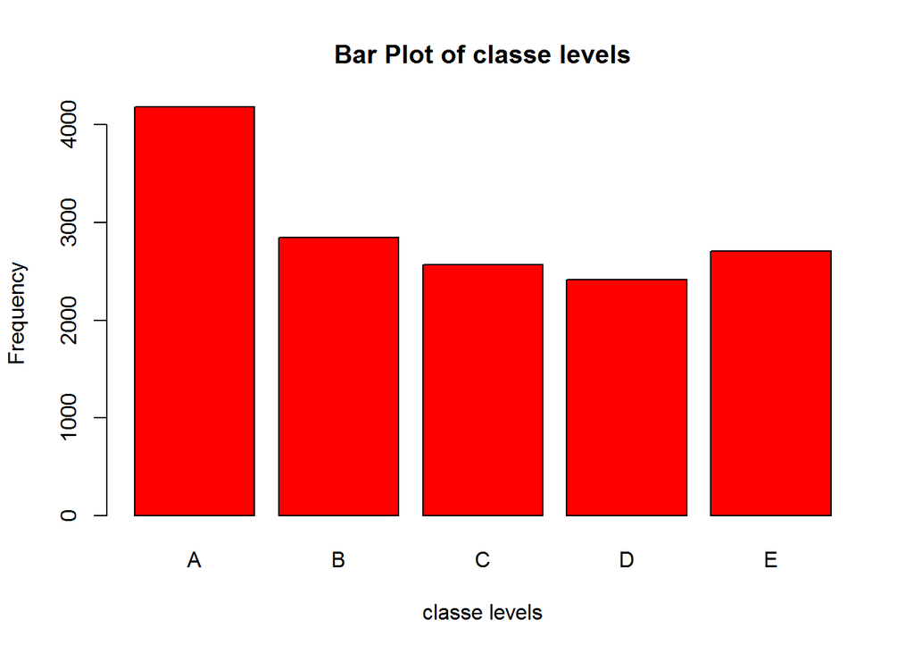

```r
#overview
plot(subTraining$classe, col="red", main="Bar Plot of classe levels", xlab="classe levels", ylab="Frequency")
```

##### Modeling

###### First Model

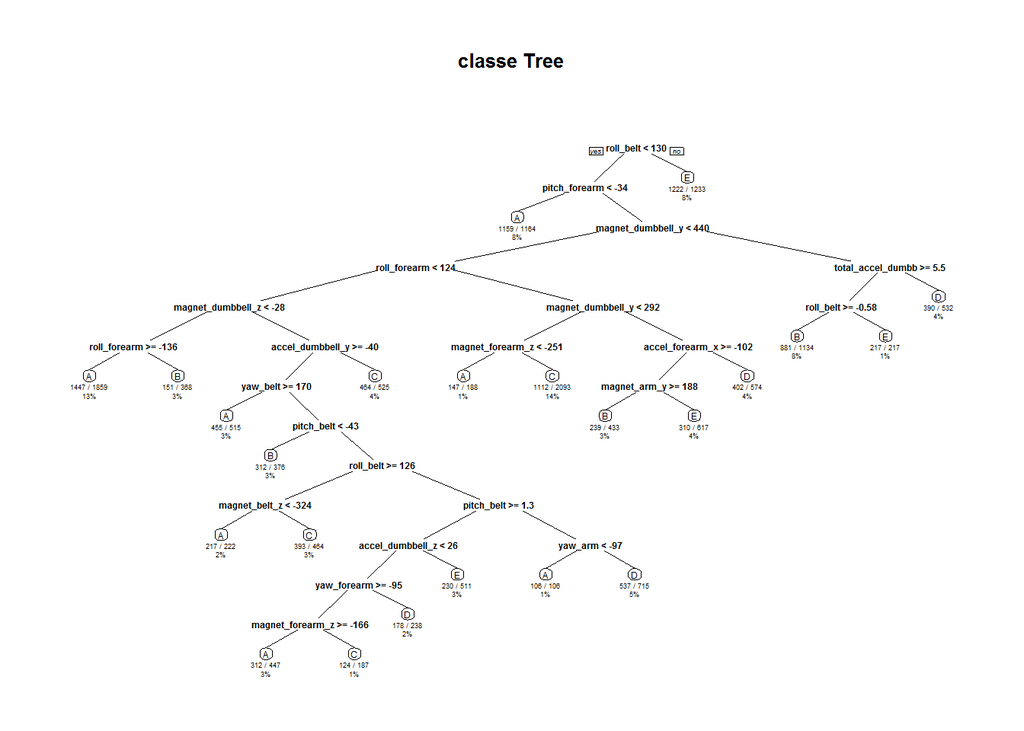

```r
mod1 <- rpart(classe ~ ., data=subTraining, method="class")
# Predicting:
pred1 <- predict(mod1, subTesting, type = "class")
# Plot of the Decision Tree
rpart.plot(mod1, main="classe Tree", extra=102, under=TRUE, faclen=0)
```

```r
##test results on subTesting data
confusionMatrix(pred1, subTesting$classe)
```

```
## Confusion Matrix and Statistics
##
##           Reference
## Prediction    A    B    C    D    E
##          A 1261  130   20   47   16
##          B   47  505   77   63   62
##          C   46  148  689  106  127
##          D   15   69   47  533   51
##          E   26   97   22   55  645
##
## Overall Statistics
##
##                Accuracy : 0.7408
##                  95% CI : (0.7283, 0.753)
##     No Information Rate : 0.2845
##     P-Value [Acc > NIR] : < 2.2e-16
##
##                   Kappa : 0.6717
##  Mcnemar's Test P-Value : < 2.2e-16
##
## Statistics by Class:
##
##                      Class: A Class: B Class: C Class: D Class: E
## Sensitivity            0.9039   0.5321   0.8058   0.6629   0.7159
## Specificity            0.9393   0.9370   0.8945   0.9556   0.9500
## Pos Pred Value         0.8555   0.6698   0.6174   0.7455   0.7633
## Neg Pred Value         0.9609   0.8930   0.9562   0.9353   0.9369
## Prevalence             0.2845   0.1935   0.1743   0.1639   0.1837
## Detection Rate         0.2571   0.1030   0.1405   0.1087   0.1315
## Detection Prevalence   0.3006   0.1538   0.2276   0.1458   0.1723
## Balanced Accuracy      0.9216   0.7346   0.8502   0.8093   0.8330
```

###### Second Model

```r
mod2 <- randomForest(classe ~. , data=subTraining, method="class")
# Predicting:
pred2 <- predict(mod2, subTesting, type = "class")
# Test results on subTesting data set:
confusionMatrix(pred2, subTesting$classe)
```

```
## Confusion Matrix and Statistics
##
##           Reference
## Prediction    A    B    C    D    E
##          A 1395    0    0    0    0
##          B    0  948    5    0    0
##          C    0    1  850    7    1
##          D    0    0    0  795    4
##          E    0    0    0    2  896
##
## Overall Statistics
##
##                Accuracy : 0.9959
##                  95% CI : (0.9937, 0.9975)
##     No Information Rate : 0.2845
##     P-Value [Acc > NIR] : < 2.2e-16
##
##                   Kappa : 0.9948
##  Mcnemar's Test P-Value : NA
##
## Statistics by Class:
##
##                      Class: A Class: B Class: C Class: D Class: E
## Sensitivity            1.0000   0.9989   0.9942   0.9888   0.9945
## Specificity            1.0000   0.9987   0.9978   0.9990   0.9995
## Pos Pred Value         1.0000   0.9948   0.9895   0.9950   0.9978
## Neg Pred Value         1.0000   0.9997   0.9988   0.9978   0.9988
## Prevalence             0.2845   0.1935   0.1743   0.1639   0.1837
## Detection Rate         0.2845   0.1933   0.1733   0.1621   0.1827
## Detection Prevalence   0.2845   0.1943   0.1752   0.1629   0.1831
## Balanced Accuracy      1.0000   0.9988   0.9960   0.9939   0.9970
```

##### Conclusion:

*Random Forest is performing better than model 1.*

#### Submission

```r
pred_subm <- predict(mod2, test_set, type="class")
pred_subm
```

```
##  1  2  3  4  5  6  7  8  9 10 11 12 13 14 15 16 17 18 19 20
##  B  A  B  A  A  E  D  B  A  A  B  C  B  A  E  E  A  B  B  B
## Levels: A B C D E
```

```r
pml_write_files = function(x){
  n = length(x)
  for(i in 1:n){
    filename = paste0("problem_id_",i,".txt")
    write.table(x[i],file=filename,quote=FALSE,row.names=FALSE,col.names=FALSE)
  }
}
pml_write_files(pred_subm)
```

### References

– 1. http://groupware.les.inf.puc-rio.br/har  
– 2.Ugulino, W.; Cardador, D.; Vega, K.; Velloso, E.; Milidiu, R.; Fuks, H. Wearable Computing: Accelerometers’ Data Classification of Body Postures and Movements. Proceedings of 21st Brazilian Symposium on Artificial Intelligence. Advances in Artificial Intelligence - SBIA 2012. In: Lecture Notes in Computer Science. , pp. 52-61. Curitiba, PR: Springer Berlin / Heidelberg, 2012. ISBN 978-3-642-34458-9. DOI: 10.1007/978-3-642-34459-6_6.  
– 3. Velloso, E.; Bulling, A.; Gellersen, H.; Ugulino, W.; Fuks, H. Qualitative Activity Recognition of Weight Lifting Exercises. Proceedings of 4th International Conference in Cooperation with SIGCHI (Augmented Human ’13) . Stuttgart, Germany: ACM SIGCHI, 2013.